# Reproducible Research: Peer Assessment 1

## Loading & Preprocessing the data

First read the data into R

```r
setwd("~/datasciencecoursera/RepRes/Ass1")
txt_file<- "activity.csv"

data_set <- read.csv(txt_file,
                 header=TRUE,   sep=",",
                 colClasses=c("numeric", "character", "numeric"))
```

Then update the date & interval variable types

```r
data_set$interval <- factor(data_set$interval)
data_set$date <- as.Date(data_set$date, format="%Y-%m-%d")
```

## What is mean total number of steps taken per day?

Create and aggregated dataset (aggregating on the date)

```r
steps_taken_per_day <- aggregate(steps ~ date, data_set, sum)
colnames(steps_taken_per_day) <- c("date", "steps")
```

Plot a histogram of the total number of steps per day

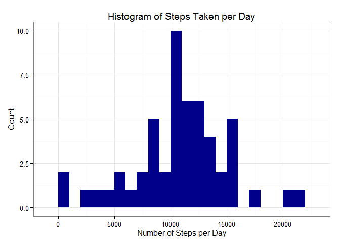

```r
require(ggplot2)
ggplot(steps_taken_per_day, aes(x = steps)) +
  geom_histogram(fill = "darkblue", binwidth = 1000) +
  labs(title="Histogram of Steps Taken per Day",
       x = "Number of Steps per Day", y = "Count") +
  theme_bw()
```

Calculate the mean & median total number of steps per day

```r
mean_steps = round(mean(steps_taken_per_day$steps, na.rm=TRUE), 2)
median_steps = round(median(steps_taken_per_day$steps, na.rm=TRUE), 2)
```

The mean number of steps:

```
## [1] 10766
```

The median number of steps:

```
## [1] 10765
```

## What is the average daily activity pattern?

Aggregate the data on interval

```r
steps_per_interval <- aggregate(data_set$steps,by = list(interval = data_set$interval),FUN=mean, na.rm=TRUE)
```

Convert to integers for plotting & plot

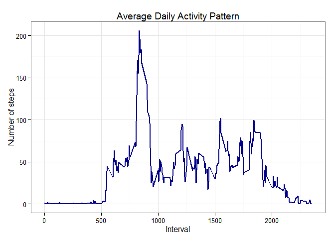

```r
steps_per_interval$interval <-
  as.integer(levels(steps_per_interval$interval)[steps_per_interval$interval])
colnames(steps_per_interval) <- c("interval", "steps")

ggplot(steps_per_interval, aes(x=interval, y=steps)) +
  geom_line(color="darkblue", size=1) +
  labs(title="Average Daily Activity Pattern", x="Interval", y="Number of steps") +
  theme_bw() + theme(legend.position = "bottom")
```

Which 5 minute interval on average across all the days in teh dataset contains the maximum number of steps?

```r
max_step_interval <- steps_per_interval[which.max(steps_per_interval$steps),]$interval
max_step_interval
```

```
## [1] 835
```